| title: “Storm Analysis” |
| --- |
| author: Aynalem Mekbib |
| date: Feb 22, 2019 |
| output: html_document |

Coursera - Reproducible Research - Project 2 Aynalem Mekbib Tuesday, January 20, 2019 Exploring the NOAA Storm Database

## Introduction

Storms and other severe weather events cause both public health and economic problems. Severe events can result in fatalities, injuries, crop and property damage. The prevention of such outcomes is a key concern. This project explores the U.S. National Oceanic and Atmospheric Administration’s (NOAA) storm database. This database tracks characteristics of major storms and weather events in the United States, including the weather event type, when and where they occur, as well as estimates of any fatalities, injuries, and crop and property damage.

## Data Processing

```r
library(knitr)
library(sqldf)
library(pdftools)
library(kableExtra)
library(tidyverse)
library(gridExtra)
library(proto)
```

## Data Processing

Storm data is downloaded from the official web site of National Oceanic and Atmospheric Administration Website.

```r
download.file("https://d396qusza40orc.cloudfront.net/repdata%2Fdata%2FStormData.csv.bz2","storms.csv.bz2")
download.file("https://d396qusza40orc.cloudfront.net/repdata%2Fpeer2_doc%2Fpd01016005curr.pdf","stormdoc.pdf", mode = "wb")
```

Download date <- Sun Feb 24 23:12:03 2019

Extract storm data

```r
 storm <- read.csv("Storms.csv.bz2", header = TRUE)
```

The storm data consists of a total of 902297 rows and 37 columns.

Extract storm documents and use Table 1 as the standard weather event names.

```r
 storminfo <- pdf_text("stormdoc.pdf")
 storminfo <- strsplit(storminfo, "\n")
 head(storminfo[[6]],40)
```

```
##  [1] "                                                                NWSI 10-1605 AUGUST 17, 2007\r"
##  [2] "In some cases, such as with Hurricane Katrina, it may be nearly impossible to determine what\r"
##  [3] "event (i.e., Storm Surge/Tide, Hurricane, Flash Flood, or High Surf) resulted in a directly-related\r"
##  [4] "death. For these situations, in order to simplify the Storm Data preparation process, it is\r"
##  [5] "appropriate to assign the death to the Hurricane (Typhoon) event. However, state this fact in the\r"
##  [6] "event narrative.\r"
##  [7] "2.1.1   Storm Data Event Table\r"
##  [8] "Event Name                       Designator           Event Name                        Designator\r"
##  [9] "Astronomical Low Tide                  Z              Hurricane (Typhoon)                   Z\r"
## [10] "Avalanche                              Z              Ice Storm                             Z\r"
## [11] "Blizzard                               Z              Lake-Effect Snow                      Z\r"
## [12] "Coastal Flood                          Z              Lakeshore Flood                       Z\r"
## [13] "Cold/Wind Chill                        Z              Lightning                             C\r"
## [14] "Debris Flow                            C              Marine Hail                           M\r"
## [15] "Dense Fog                              Z              Marine High Wind                      M\r"
```

[output cut: 25 more lines]

# Data Transformation

Data with reported fatalities, injuries or crop or property damage is selected for this analysis.

```r
  stormselect <- storm %>%
                filter(FATALITIES >  0 | INJURIES > 0 | PROPDMG > 0 | CROPDMG > 0) %>%
              select(BGN_DATE, EVTYPE, FATALITIES, INJURIES, PROPDMG, PROPDMGEXP, CROPDMG, CROPDMGEXP) %>%
              droplevels()
  str(stormselect)
```

```
## 'data.frame':    254633 obs. of  8 variables:
##  $ BGN_DATE  : Factor w/ 12942 levels "1/1/1972 0:00:00",..: 5034 5034 3273 8933 1674 1674 1705 318 3066 3066 ...
##  $ EVTYPE    : Factor w/ 488 levels "   HIGH SURF ADVISORY",..: 407 407 407 407 407 407 407 407 407 407 ...
##  $ FATALITIES: num  0 0 0 0 0 0 0 0 1 0 ...
##  $ INJURIES  : num  15 0 2 2 2 6 1 0 14 0 ...
##  $ PROPDMG   : num  25 2.5 25 2.5 2.5 2.5 2.5 2.5 25 25 ...
##  $ PROPDMGEXP: Factor w/ 16 levels "","-","+","0",..: 14 14 14 14 14 14 14 14 14 14 ...
##  $ CROPDMG   : num  0 0 0 0 0 0 0 0 0 0 ...
##  $ CROPDMGEXP: Factor w/ 8 levels "","?","0","B",..: 1 1 1 1 1 1 1 1 1 1 ...
```

Add a column for the year

```r
stormselect$YEAR <- as.numeric(format(as.Date(stormselect$BGN_DATE, "%m/%d/%Y %H :%M :%S"), "%Y"))
```

Descriptions of columns selected for this analysis:

```r
   Column        Description
  BDN_DATE      Begin date
  EVTYPE          Event type
  FATALITIES      Fatalities attributable to the event
  INJURIES      Injuries attributable to the event
  PROPDMG         Property damage estimate (USD)
  PROPDMGEXP      Magnitude of property damage Estimate
  CROPDMG   Crop  Crop damage estimate (USD)
  CROPDMGEXP      Magnitude of crop damage estimate
  YEAR          Year of the event happened
```

Create factors

```r
 stormselect$CROPDMGEXP <- factor(stormselect$CROPDMGEXP)
 stormselect$PROPDMGEXP <- factor(stormselect$PROPDMGEXP)
```

Display data

```r
kable(head(stormselect,5), booktabs=TRUE) %>%
  kable_styling(latex_options="scale_down")
```

| BGN_DATE | EVTYPE | FATALITIES | INJURIES | PROPDMG | PROPDMGEXP | CROPDMG | CROPDMGEXP | YEAR |
| --- | --- | --- | --- | --- | --- | --- | --- | --- |
| 4/18/1950 0:00:00 | TORNADO | 0 | 15 | 25.0 | K | 0 |  | 1950 |
| 4/18/1950 0:00:00 | TORNADO | 0 | 0 | 2.5 | K | 0 |  | 1950 |
| 2/20/1951 0:00:00 | TORNADO | 0 | 2 | 25.0 | K | 0 |  | 1951 |
| 6/8/1951 0:00:00 | TORNADO | 0 | 2 | 2.5 | K | 0 |  | 1951 |
| 11/15/1951 0:00:00 | TORNADO | 0 | 2 | 2.5 | K | 0 |  | 1951 |

### Edit storm events

Remove leading/trailing blanks and convert to upper case event names  
Catagorize data into the 48 weather event types as defined on Table 1 above. For no matching storm event, categorize it into ‘other’ group.

```r
stormselect$EVTYPE <- as.character(stormselect$EVTYPE)
stormselect$EVTYPE <- str_trim(stormselect$EVTYPE)
stormselect$EVTYPE <- toupper(stormselect$EVTYPE)
stormselect$EVTYPE <- gsub("ASTRONOMICA.*", "ASTRONOMICAL LOW TIDE", stormselect$EVTYPE)
stormselect$EVTYPE <- gsub("^AVALANC.*", "AVALANCHE", stormselect$EVTYPE)
stormselect$EVTYPE <- gsub(".*BLIZZARD$|^BLIZ.*|BLOWING SNOW", "BLIZZARD", stormselect$EVTYPE)
stormselect$EVTYPE <- gsub('^COASTA.*','COASTAL FLOOD', stormselect$EVTYPE)
stormselect$EVTYPE <- gsub('SNOW/COLD|^(.*BITTER.*|UNSEAS.*)\\sCOLD$|^(COLD|LOW)\\sTEMPERATURE$|^(COLD$|COLD.*)|^COOL.*', 'COLD/WIND CHILL', stormselect$EVTYPE)
stormselect$EVTYPE <- gsub('EXTENDED COLD|^COLD\\s(WAVE|TEMPERATURE|AND.*)|COLD/WINDS', 'COLD/WIND CHILL', stormselect$EVTYPE)
stormselect$EVTYPE <- gsub("^FOG.*", "DENSE FOG", stormselect$EVTYPE)
stormselect$EVTYPE <- gsub(".*SLIDE$|.*SLUMP$|.*SLIDES$|^EROSIO.*|.*EROSION$|DAM BREAK|^MUD.*", "DEBRIS FLOW", stormselect$EVTYPE)
stormselect$EVTYPE <- gsub('DROUGHT.*HEAT$','DROUGHT', stormselect$EVTYPE)
stormselect$EVTYPE <- gsub('\\bDUST DEVIL WATERSPOUT\\b','DUST DEVIL', stormselect$EVTYPE)
stormselect$EVTYPE <- gsub('^DUS.* WINDS$|.*DUST$','DUST STORM', stormselect$EVTYPE)
stormselect$EVTYPE <- gsub('^EXT.*HEAT$|^HEAT WAVE.*|^RECOR.*HEAT$','EXCESSIVE HEAT', stormselect$EVTYPE)
stormselect$EVTYPE <- gsub('^HYP.*|EXTREM.*CHILL$|^REC.*COLD$|EXTR.*COLD$','EXTREME COLD/WIND CHILL', stormselect$EVTYPE)
stormselect$EVTYPE <- gsub('^FLAS.*FLOO(D|DING)$|^(RIV.*|FLOOD/FLASH/)FLOOD$|^FLOOD/FLA.*|^FLASH FLOOD.*','FLASH FLOOD', stormselect$EVTYPE)
stormselect$EVTYPE <- gsub('^BREAKUP.*|^FLOODIN.*|\\b^FLOODS\\b|^FLOOD/^RUR.*FLOOD$|\\bHIGH WATER\\b|^SMA.*FLOOD$','FLOOD', stormselect$EVTYPE)
stormselect$EVTYPE <- gsub("^URBA.*|^MAJO.*|^(MINO.*|SNOWMELT).*FLOODING| ^FLOOD\\/RAI.*|^FLOOD\\s&\\sHEAV.*|^RIVE.*|RURAL.*", "FLOOD", stormselect$EVTYPE)
stormselect$EVTYPE <- gsub('.*FREEZING RAIN$','FREEZING FOG', stormselect$EVTYPE)
stormselect$EVTYPE <- gsub("^BLAC.*|^GLAZ.*|^FREEZ.*|^AGRICUL.*", "FREEZING FOG", stormselect$EVTYPE)
stormselect$EVTYPE <- gsub('^FROS.*|DAMAGING FREEZE|HARD FREEZE|EARLY FROST','FROST/FREEZE', stormselect$EVTYPE)
stormselect$EVTYPE <- gsub("^HAIL.*|.*HAIL$", "HAIL", stormselect$EVTYPE)
stormselect$EVTYPE <- gsub("WARM WEATHER|^UNSEASONABLY WAR.*", "HEAT", stormselect$EVTYPE)
stormselect$EVTYPE <- gsub('^EXC.*WETNESS$|^HEAVY RAI.*|^RAI.*|HVY RAIN|.*RAINFALL$|.*SHOWER$|.*PRECIPITATION$|^UNSE.*RAIN$|^MIX.*PRECIP$', "HEAVY RAIN", stormselect$EVTYPE)
stormselect$EVTYPE <- gsub('^SNOW\\/.*|^SNOW ACCUM.*|^SNOW AND HEAV.*|^REC.*SNOW$|^HEAVY SNO.*','HEAVY SNOW', stormselect$EVTYPE)
stormselect$EVTYPE <- gsub('^SNOW$|LAT.*SNOW$|LIGHT SNO.*|^HEAVY LAKE SNOW$|EXCESSIVE SNOW|^HEAVY.*SNO.*SHOWER$','HEAVY SNOW', stormselect$EVTYPE)
stormselect$EVTYPE <- gsub("HAZARDOUS SURF|^HEAVY SUR.*|HIGH SUR.*|HIGH WAVES|^HIGH$|^ROUGH SURF$", "HIGH SURF", stormselect$EVTYPE)
stormselect$EVTYPE <- gsub('WHIRLWIND|^WIND.*|^SNOW/HIGH WIND|^HIGH.*WIN(D|DS).*|^*NON.*(WIND$|DAMAGE$)','HIGH WIND', stormselect$EVTYPE)
stormselect$EVTYPE <- gsub("^HURRICANE.*|^HURR.|^TYPHOON", "HURRICANE", stormselect$EVTYPE)
stormselect$EVTYPE <- gsub('\\bFALLING SNOW/ICE\\b|^IC.*|^SNOW/IC.*|^SNOW AND IC.*|^SNOW/ IC.*','ICE STORM', stormselect$EVTYPE)
stormselect$EVTYPE <- gsub('^SNOW.*SQUAL.*|^LAKE EFFEC.*','LAKE-EFFECT SNOW', stormselect$EVTYPE)
stormselect$EVTYPE <- gsub('LAKE FLOOD','LAKESHORE FLOOD', stormselect$EVTYPE)
stormselect$EVTYPE <- gsub('^LIGHTN.*|^LIGHTING|^LIGNT.*','LIGHTNING', stormselect$EVTYPE)
stormselect$EVTYPE <- gsub('^WIND AND WAVE','MARINE HIGH WIND', stormselect$EVTYPE)
stormselect$EVTYPE <- gsub('^MARINE TSTM.*','MARINE THUNDERSTORM WIND', stormselect$EVTYPE)
stormselect$EVTYPE <- gsub("^RIP CURRE.*", "RIP CURRENT", stormselect$EVTYPE)
stormselect$EVTYPE <- gsub('^SNOW/SL.*|SLEET/ICE STORM','SLEET', stormselect$EVTYPE)
stormselect$EVTYPE <- gsub('^ROGU.|.*STORM SURGE$|^RAPID.*|.*SURGE\\/TIDE$|^TIDAL.*','STORM SURGE/TIDE', stormselect$EVTYPE)
stormselect$EVTYPE <- gsub('.*SWELLS$|DROWNING|.*TIDES$|^(ROUGH|HIGH|HEAVY).*SEAS$|^STORM.*WAVE$','STORM SURGE/TIDE', stormselect$EVTYPE)
stormselect$EVTYPE <- gsub('^STRONG WINDS|^GUSTY.*|^DRY.*WINDS$|^MICRO.*|DOWNBURST|.*MICROBURST$|^GRADIENT.*|^STORM FORCE WINDS$','STRONG WIND', stormselect$EVTYPE)
stormselect$EVTYPE <- gsub("^THU.*|^SEVER.*|^TUNDER.*|^TST.*", "THUNDERSTORM WIND", stormselect$EVTYPE)
stormselect$EVTYPE <- gsub('.*TORNADO$|^TORN.*|.*LANDSPOUT$|^GUSTNADO','TORNADO', stormselect$EVTYPE)
stormselect$EVTYPE <- gsub("^TROPICAL STOR.*", "TROPICAL STORM", stormselect$EVTYPE)
stormselect$EVTYPE <- gsub("^WATERSPOU.*", "WATERSPOUT", stormselect$EVTYPE)
stormselect$EVTYPE <- gsub(".*FIR(E|ES)$", "WILDFIRE", stormselect$EVTYPE)
stormselect$EVTYPE <- gsub("^WINTER STOR.*", "WINTER STORM", stormselect$EVTYPE)
stormselect$EVTYPE <- gsub('^(HEAVY|WINT.*).MIX$', "WINTER WEATHER", stormselect$EVTYPE)
stormselect$EVTYPE <- gsub('^OTHER|\\?|.*COUNTY$|^MARINE ACCIDENT|^MARINE MISHAP','OTHERS', stormselect$EVTYPE)
```

### Fatalities

Find the top 10 weather events that caused the most fatalities.

```r
sql_string <- "select EVTYPE,
                sum(fatalities) fatal
                from stormselect
                group by EVTYPE
                order by fatal desc";
stormfatal <- sqldf(sql_string,stringsAsFactors = FALSE);
stormfataltop10 <- head(stormfatal,10)
```

### Injuries

Find the top 10 weather events that caused the most injuries

```r
sql_string <- "select EVTYPE,
              sum(injuries) injury
              from stormselect
              group by EVTYPE
              order by injury desc";

storminjury <- sqldf(sql_string,stringsAsFactors = FALSE);
storminjurytop10 <- head(storminjury,10)
```

### Top 10 fatality for tornado

```r
sql_string <- "select YEAR,
                sum(fatalities) TOTALFATAL
                from stormselect
                where EVTYPE = 'TORNADO'
                group by YEAR
                order by TOTALFATAL desc";

stormfatalyear <- sqldf(sql_string,stringsAsFactors = FALSE);
stormfatalyeartop10 <- head(stormfatalyear,10);
```

### Top 10 injury for tornado

```r
sql_string <- "select YEAR,
                sum(injuries) TOTALINJURY
                from stormselect
                where EVTYPE = 'TORNADO'
                group by YEAR
                order by TOTALINJURY desc";

storminjuryyear <- sqldf(sql_string,stringsAsFactors = FALSE);
storminjuryyeartop10 <- head(storminjuryyear,10);
```

### Evaluate Crop damage

```r
unique(levels(stormselect$CROPDMGEXP))
```

```
## [1] ""  "?" "0" "B" "k" "K" "m" "M"
```

```r
stormselect[stormselect$CROPDMGEXP == '^B'] <- '1000000000'
stormselect[stormselect$CROPDMGEXP == '^(m|M)'] <- '1000000'
stormselect[stormselect$CROPDMGEXP == '^(K|k)'] <- '1000'
stormselect[stormselect$CROPDMGEXP == '^($|?|0'] <- '1'
stormselect$CROPDMGEXP <- as.numeric(stormselect$CROPDMGEXP)
stormselect$CROPDMGEXP[is.na(stormselect$CROPDMGEXP)]=0;
```

Get top 10 crop damages

```r
sql_string <- "select  EVTYPE,
                  sum(CROPDMG * CROPDMGEXP) TOTALCROPDMG
                  from stormselect
                  group by EVTYPE
                  order by TOTALCROPDMG desc";
stormselectcropdmg <- sqldf(sql_string,stringsAsFactors = FALSE);
stormselectcropdmgtop10 <- head(stormselectcropdmg,10)
stormselectcropdmgtop10
```

```
##               EVTYPE TOTALCROPDMG
## 1               HAIL   3520309.58
## 2  THUNDERSTORM WIND   1170900.54
## 3        FLASH FLOOD   1142571.38
## 4              FLOOD   1071572.06
## 5            TORNADO    600320.44
## 6            DROUGHT    228325.64
## 7          HIGH WIND    129837.68
## 8         HEAVY RAIN     79526.80
## 9          HURRICANE     77810.68
## 10          WILDFIRE     58182.66
```

```r
sql_string <- "select YEAR,
                sum(CROPDMG * CROPDMGEXP) TOTALCROPDMG
                from stormselect
                where EVTYPE = 'TORNADO'
                group by YEAR
                order by TOTALCROPDMG desc";

stormcropdmgyear <- sqldf(sql_string,stringsAsFactors = FALSE);
stormcropdmgyeartop10 <- head(stormcropdmgyear,10);
```

### Property damage

Identify factors  
B=1000000000, M=1000000, K=1000, H=100, 2 = 100, 3=1000, 4=10000, 5=100000, 6=1000000, 7=10000000,($,+,-,0) = 1

```r
unique(toupper(levels(stormselect$PROPDMGEXP)))
```

```
##  [1] ""  "-" "+" "0" "2" "3" "4" "5" "6" "7" "B" "H" "K" "M"
```

```r
stormselect[stormselect$PROPDMGEXP == '^B'] <- '1000000000';
stormselect[stormselect$PROPDMGEXP == '^7'] <- '10000000';
stormselect[stormselect$PROPDMGEXP == '^(m|M|6)'] <- '1000000';
stormselect[stormselect$PROPDMGEXP == '^5'] <- '100000';
stormselect[stormselect$PROPDMGEXP == '^4'] <- '10000';
stormselect[stormselect$PROPDMGEXP == '^(k|K|3)'] <- '1000';
stormselect[stormselect$PROPDMGEXP == '^(h|H|2)'] <- '100';
stormselect[stormselect$PROPDMGEXP == '^($|+|-|0)'] <- '1';
stormselect$PROPDMGEXP <- as.numeric(stormselect$PROPDMGEXP)
stormselect$PROPDMGEXP[is.na(stormselect$PROPDMGEXP)]=0
```

Get top 10 property damages

```r
sql_string <- "select EVTYPE,
              sum(PROPDMG * PROPDMGEXP) TOTALPROPDMG
              from stormselect
              group by EVTYPE
              order by TOTALPROPDMG desc";
stormselectpropdmg <- sqldf(sql_string,stringsAsFactors = FALSE);
stormselectpropdmgtop10 <- head(stormselectpropdmg,10)
stormselectpropdmgtop10
```

```
##               EVTYPE TOTALPROPDMG
## 1            TORNADO     45116382
## 2  THUNDERSTORM WIND     37269790
## 3        FLASH FLOOD     20874395
## 4              FLOOD     13378196
## 5               HAIL      9813944
## 6          LIGHTNING      8447211
## 7          HIGH WIND      5398214
## 8         HEAVY SNOW      1885610
## 9       WINTER STORM      1869138
## 10          WILDFIRE      1764723
```

Top 10 total property damage

```r
sql_string <- "select YEAR,
                sum(PROPDMG * PROPDMGEXP) TOTALPROPDMG
                from stormselect
                where EVTYPE = 'TORNADO'
                group by YEAR
                order by TOTALPROPDMG desc";

stormpropdmgyear <- sqldf(sql_string,stringsAsFactors = FALSE);
stormpropdmgyeartop10 <- head(stormpropdmgyear,10);
```

## Results

Results are analyzed using the top 10 severe climate events.

### Across the United States, which types of events (as indicated in the EVTYPE variable) are most harmful with respect to population health ?

The graph below shows the top 10 weather events responsible for the most human injuries and fatalities.

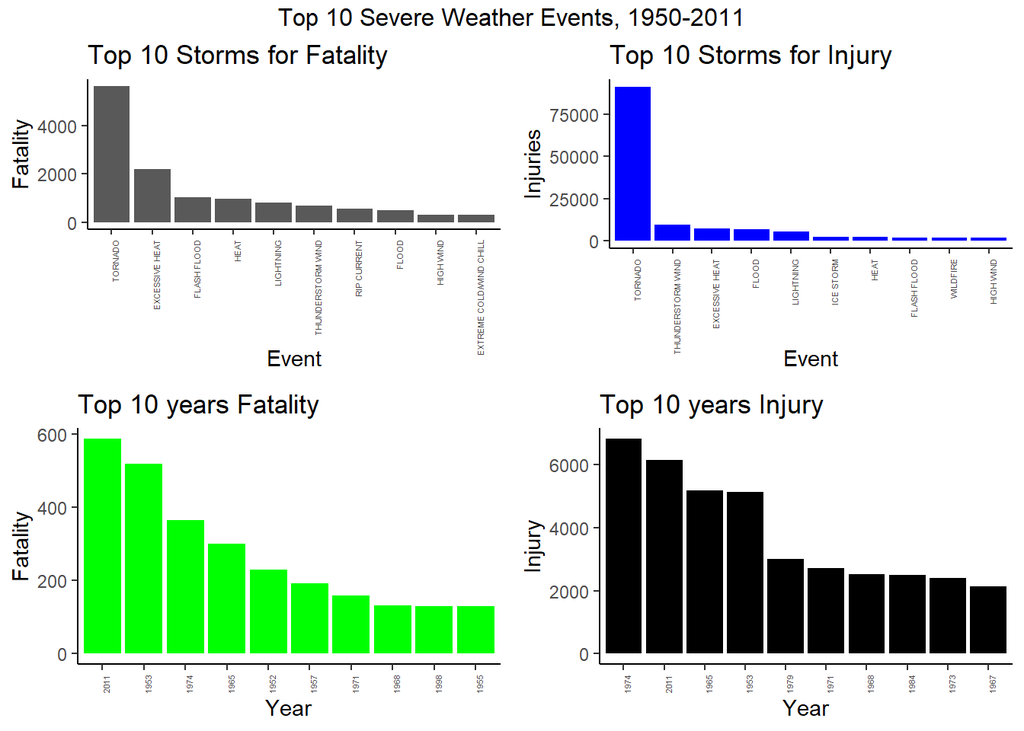

```r
p <- ggplot(stormfataltop10, aes(x = reorder(EVTYPE,-fatal), y = fatal)) +
    geom_bar(stat="identity") +
  theme_classic() +
  labs(x="Event", y = "Fatality") +
  ggtitle("Top 10 Storms for Fatality") +
  theme(axis.text.x = element_text(angle = 90, size=4, hjust = 1))

q <- ggplot(data=storminjurytop10, aes(x = reorder(EVTYPE, -injury), y = injury)) +
  geom_bar(stat= "identity",fill = "blue") +
  theme_classic() +
  labs(x="Event", y = "Injuries") +
  ggtitle("Top 10 Storms for Injury") +
  theme(axis.text.x = element_text(angle = 90, size=4, hjust = 1))

u <- ggplot(data=stormfatalyeartop10, aes(x = reorder(YEAR, -TOTALFATAL), y = TOTALFATAL)) +
  geom_bar(stat= "identity",fill = "green") +
  theme_classic() +
  labs(x="Year", y = "Fatality") +
  ggtitle("Top 10 years Fatality")  +
  theme(axis.text.x = element_text(angle = 90, size=4, hjust = 1))
v <- ggplot(data=storminjuryyeartop10, aes(x = reorder(YEAR, -TOTALINJURY), y = TOTALINJURY)) +
  geom_bar(stat= "identity",fill = "black") +
  theme_classic() +
  labs(x="Year", y = "Injury") +
  ggtitle("Top 10 years Injury")  +
  theme(axis.text.x = element_text(angle = 90, size=4, hjust = 1))
s <- grid.arrange(p,q,u,v, nrow=2, top ="Top 10 Severe Weather Events, 1950-2011")
```

```r
print(s)
```

### Across the United States, which types of events have the greatest economic consequences ?

The graph below shows the top 10 weather events responsible for property and crop daamages.

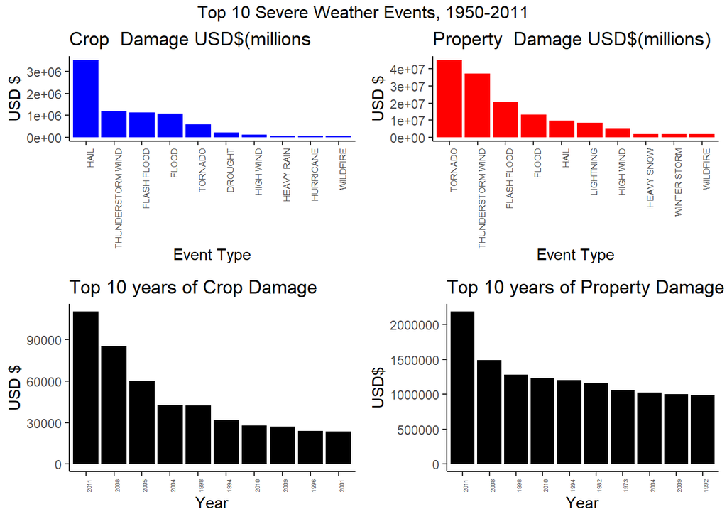

```r
p <- ggplot(data=stormselectcropdmgtop10, aes(x=reorder(EVTYPE, -TOTALCROPDMG), y = TOTALCROPDMG)) +
     geom_bar(stat="identity", fill="blue") +
     theme_classic() +
     labs(x="Event Type", y="USD $") +
     ggtitle("Crop  Damage USD$(millions") +
     theme(axis.text.x = element_text(angle = 90, size=6, hjust = 1))

q <- ggplot(data=stormselectpropdmgtop10, aes(x=reorder(EVTYPE, -TOTALPROPDMG), y=TOTALPROPDMG)) +
    geom_bar(stat="identity", fill="red") +
    theme_classic() +
    labs(x="Event Type", y="USD $") +
    ggtitle("Property  Damage USD$(millions)") +
    theme(axis.text.x = element_text(angle = 90, size=6, hjust = 1))
u <- ggplot(data=stormcropdmgyeartop10, aes(x = reorder(YEAR, -TOTALCROPDMG), y = TOTALCROPDMG)) +
  geom_bar(stat= "identity",fill = "black") +
  theme_classic() +
  labs(x="Year", y = "USD $") +
  ggtitle("Top 10 years of Crop Damage")  +
  theme(axis.text.x = element_text(angle = 90, size=4, hjust = 1))
v <- ggplot(data=stormpropdmgyeartop10, aes(x = reorder(YEAR, -TOTALPROPDMG), y = TOTALPROPDMG)) +
  geom_bar(stat= "identity",fill = "black") +
  theme_classic() +
  labs(x="Year", y = "USD$") +
  ggtitle("Top 10 years of Property Damage")  +
  theme(axis.text.x = element_text(angle = 90, size=4, hjust = 1))
s <- grid.arrange(p,q,u,v,nrow=2, top ="Top 10 Severe Weather Events, 1950-2011")
```

```r
print(s)
```

# Conclusion